# BAX452_Homework3_ArjunMahesh

Arjun Velmurugan Mahesh

2023-01-28

[20 points] Q1. For the above dataset (Dependent variable: heart_attack) How would you choose a sample subset (such as missing value, nulls, empty columns) of this dataset? What criteria would you consider when selecting a training subset from the above dataset (such as balanced distribution between training and test for the treated observations) ?

Randomly split the dataset into test and training sets using 80% observations as training set. Fit a simple linear regression model (full model) to predict the heart attack probability and test your model against the test set. Explain your model and obtain the R^2 for the predictions of the test data set (i.e., a true OOS R^2).

```r
q1 = read.csv("heart.csv")
summary(q1)
```

```
##    past_pain        density           age            weight
##  Min.   : 0.00   Min.   :0.995   Min.   :22.00   Min.   :118.5
##  1st Qu.:12.78   1st Qu.:1.043   1st Qu.:35.00   1st Qu.:159.0
##  Median :18.80   Median :1.056   Median :43.00   Median :175.8
##  Mean   :18.59   Mean   :1.056   Mean   :43.68   Mean   :178.3
##  3rd Qu.:24.00   3rd Qu.:1.071   3rd Qu.:51.00   3rd Qu.:195.8
##  Max.   :45.10   Max.   :1.109   Max.   :81.00   Max.   :363.1
##
##      height       fat_free_wt    family_record     neck_dim
##  Min.   :29.50   Min.   :107.9   Mode:logical   Min.   :31.10
##  1st Qu.:68.38   1st Qu.:131.1   NA's:240       1st Qu.:36.40
##  Median :70.25   Median :141.3                  Median :37.90
##  Mean   :70.21   Mean   :143.7                  Mean   :37.94
##  3rd Qu.:72.25   3rd Qu.:153.9                  3rd Qu.:39.40
##  Max.   :77.75   Max.   :240.5                  Max.   :51.20
##  NA's   :1       NA's   :1
##    chest_dim        abdom_dim      past_record       hip_dim
##  Min.   : 79.30   Min.   : 69.40   Mode:logical   Min.   : 85.0
##  1st Qu.: 94.15   1st Qu.: 84.58   NA's:240       1st Qu.: 95.6
##  Median : 99.60   Median : 90.80                  Median : 99.3
##  Mean   :100.46   Mean   : 92.07                  Mean   : 99.9
##  3rd Qu.:104.95   3rd Qu.: 98.65                  3rd Qu.:103.1
##  Max.   :136.20   Max.   :148.10                  Max.   :147.7
##  NA's   :4                                        NA's   :2
##    thigh_dim        knee_dim       wrist_dim       ankle_dim
##  Min.   :47.20   Min.   :33.00   Min.   :10.40   Min.   :19.10
##  1st Qu.:56.05   1st Qu.:36.90   1st Qu.:10.57   1st Qu.:22.00
##  Median :58.90   Median :38.40   Median :10.75   Median :22.80
##  Mean   :59.44   Mean   :38.52   Mean   :10.75   Mean   :23.11
##  3rd Qu.:62.30   3rd Qu.:39.80   3rd Qu.:10.93   3rd Qu.:24.00
##  Max.   :87.30   Max.   :49.10   Max.   :11.10   Max.   :33.90
##  NA's   :1                       NA's   :238
##    biceps_dim     forearm_dim     wrist_dim.1     heart_attack
##  Min.   :24.80   Min.   :21.00   Min.   :15.80   Min.   :18.10
##  1st Qu.:30.20   1st Qu.:27.30   1st Qu.:17.60   1st Qu.:23.10
##  Median :32.00   Median :28.70   Median :18.20   Median :24.85
##  Mean   :32.25   Mean   :28.66   Mean   :18.19   Mean   :25.30
##  3rd Qu.:34.10   3rd Qu.:30.00   3rd Qu.:18.80   3rd Qu.:27.05
##  Max.   :45.00   Max.   :34.90   Max.   :21.40   Max.   :48.90
##  NA's   :1
```

```r
##When we have missing data sometimes we can ignore a column with a lot of missing data
##If there are still NAs in the dataframe and the number is very low, we can remove the rows
##If we still want to keep the rows in the data, we can predict or make guesses for what the value for the missing entry could be
q1<-q1[,c(-7,-11,-15)] ##removing the columns that are sparsely populated
q1<-na.omit(q1) ##removing rows with NA's
summary(q1)
```

```
##    past_pain        density           age            weight
##  Min.   : 0.00   Min.   :0.995   Min.   :22.00   Min.   :118.5
##  1st Qu.:12.90   1st Qu.:1.042   1st Qu.:37.00   1st Qu.:159.4
##  Median :18.80   Median :1.056   Median :43.00   Median :175.4
##  Mean   :18.74   Mean   :1.056   Mean   :44.19   Mean   :178.5
##  3rd Qu.:24.15   3rd Qu.:1.070   3rd Qu.:52.00   3rd Qu.:195.8
##  Max.   :45.10   Max.   :1.109   Max.   :81.00   Max.   :363.1
##      height       fat_free_wt       neck_dim       chest_dim
##  Min.   :29.50   Min.   :107.9   Min.   :31.10   Min.   : 79.30
##  1st Qu.:68.50   1st Qu.:131.2   1st Qu.:36.40   1st Qu.: 94.25
##  Median :70.25   Median :141.3   Median :37.85   Median : 99.55
##  Mean   :70.19   Mean   :143.8   Mean   :37.95   Mean   :100.53
##  3rd Qu.:72.25   3rd Qu.:154.0   3rd Qu.:39.40   3rd Qu.:105.17
##  Max.   :77.75   Max.   :240.5   Max.   :51.20   Max.   :136.20
##    abdom_dim         hip_dim         thigh_dim        knee_dim
##  Min.   : 69.40   Min.   : 85.00   Min.   :47.20   Min.   :33.00
##  1st Qu.: 85.22   1st Qu.: 95.60   1st Qu.:56.10   1st Qu.:36.92
##  Median : 90.80   Median : 99.20   Median :58.90   Median :38.50
##  Mean   : 92.26   Mean   : 99.82   Mean   :59.42   Mean   :38.54
##  3rd Qu.: 98.80   3rd Qu.:102.67   3rd Qu.:62.10   3rd Qu.:39.80
##  Max.   :148.10   Max.   :147.70   Max.   :87.30   Max.   :49.10
##    ankle_dim       biceps_dim     forearm_dim     wrist_dim.1
##  Min.   :19.10   Min.   :24.80   Min.   :21.00   Min.   :15.80
##  1st Qu.:22.00   1st Qu.:30.30   1st Qu.:27.32   1st Qu.:17.60
##  Median :22.80   Median :32.00   Median :28.70   Median :18.25
##  Mean   :23.12   Mean   :32.25   Mean   :28.65   Mean   :18.21
##  3rd Qu.:24.00   3rd Qu.:34.08   3rd Qu.:29.98   3rd Qu.:18.80
##  Max.   :33.90   Max.   :45.00   Max.   :34.90   Max.   :21.40
##   heart_attack
##  Min.   :18.10
##  1st Qu.:23.12
##  Median :24.85
##  Mean   :25.34
##  3rd Qu.:26.98
##  Max.   :48.90
```

```r
##now we have a dataset with no NA's
##now we train and test split the data
set.seed(6314) #pseudo random split initialisation
sample <- sample.split(q1[,1], SplitRatio = 0.8) ## splits data in training and test, with 80% of the df for training
train  <- subset(q1, sample == TRUE) #making the train dataset
test   <- subset(q1, sample == FALSE) #making the test dataset


model1 <- lm(formula = heart_attack ~ ., data = train )  #Linear modeling heart_attack on all other params
summary(model1) #looking at the summary of the model
```

```
##
## Call:
## lm(formula = heart_attack ~ ., data = train)
##
## Residuals:
##     Min      1Q  Median      3Q     Max
## -4.6716 -0.5384  0.0582  0.5366  2.3762
##
## Coefficients:
##               Estimate Std. Error t value Pr(>|t|)
## (Intercept) -58.564522  85.349031  -0.686 0.493553
## past_pain    -0.091817   0.210801  -0.436 0.663715
## density      46.782562  77.066674   0.607 0.544649
## age          -0.004018   0.008501  -0.473 0.637092
## weight        0.082290   0.023362   3.522 0.000552 ***
## height       -0.138142   0.022742  -6.074 8.15e-09 ***
## fat_free_wt  -0.116543   0.029953  -3.891 0.000144 ***
## neck_dim      0.184557   0.059403   3.107 0.002223 **
## chest_dim     0.140620   0.024996   5.626 7.64e-08 ***
## abdom_dim     0.125132   0.028312   4.420 1.77e-05 ***
## hip_dim       0.055217   0.038200   1.445 0.150202
## thigh_dim     0.094742   0.041644   2.275 0.024174 *
## knee_dim     -0.135969   0.066876  -2.033 0.043620 *
## ankle_dim     0.250071   0.094108   2.657 0.008642 **
## biceps_dim    0.056073   0.044160   1.270 0.205927
## forearm_dim   0.038364   0.053355   0.719 0.473134
## wrist_dim.1   0.051357   0.149359   0.344 0.731393
## ---
## Signif. codes:  0 '***' 0.001 '**' 0.01 '*' 0.05 '.' 0.1 ' ' 1
##
## Residual standard error: 0.9439 on 167 degrees of freedom
## Multiple R-squared:  0.9417, Adjusted R-squared:  0.9361
## F-statistic: 168.6 on 16 and 167 DF,  p-value: < 2.2e-16
```

```r
prediction<- predict(model1, test) #predictions using the test dataset
y_train <- train$heart_attack
y_test    <- test$heart_attack

SS.total      <- sum((y_test - mean(y_train))^2)
SS.residual   <- sum((y_test - prediction)^2)
SS.regression <- sum((prediction - mean(y_test))^2)
SS.total - (SS.regression+SS.residual)
```

```
## [1] -63.8168
```

```r
# [1] -63.8168

# NOT the fraction of variability explained by the model
test.rsq <- 1 - SS.residual/SS.total
test.rsq
```

```
## [1] 0.8776176
```

```r
#[1] 0.8776176
sprintf("The R-square from the generalized lineaer model is: %.4f",test.rsq)
```

```
## [1] "The R-square from the generalized lineaer model is: 0.8776"
```

Q2. [10 points] Explain cross-validation and highlight the problems that may be associated with a cross-validation approach.

Ans: Cross-validation methods are a set of methods that measure test errors by splitting data into a training and test set. In these methods we “hold-out” a set of observations to apply the startistical modeling we decided by training on the data-sets that weren’t held-out.

For ease of use we call these data sets, training and test datasets

The issue with cross validation is that it only gives us an estimate of the error terms in question, we do not however have an understanding of the real value. The value gets more and more accurate with more iterations and the iterational process is a drawback.

Q3. Use only the training sets from question 1 and estimate an 8-fold cross-validation to estimate the R^2 of the full model. e., use cross-validation to train (on 7/8 of the training set) and evaluate (on 1/8 of the training set). Calculate the mean R^2 from the 8-fold cross-validation and compare it with the R^2 from question 1. Please explain your observation.

```r
# Perform 8-fold cross-validation
set.seed(6314)
cv_results <- trainControl(method = "cv", number = 8, returnResamp = "all", savePredictions = TRUE)

#lambda_grid <- expand.grid(lambda = seq(0, 1, length = 100)) #why?

model_cv <- train(heart_attack ~ ., data = train, method = "lm", trControl = cv_results)
print(model_cv)
```

```
## Linear Regression
##
## 184 samples
##  16 predictor
##
## No pre-processing
## Resampling: Cross-Validated (8 fold)
## Summary of sample sizes: 161, 161, 162, 159, 161, 161, ...
## Resampling results:
##
##   RMSE      Rsquared   MAE
##   1.544136  0.8798833  0.7999337
##
## Tuning parameter 'intercept' was held constant at a value of TRUE
```

```r
model_cv$pred
```

```
##         pred  obs rowIndex intercept Resample
## 1   32.20750 32.0       20      TRUE    Fold1
## 2   21.18209 20.4       30      TRUE    Fold1
## 3   29.52709 29.3       37      TRUE    Fold1
## 4   29.12411 28.2       40      TRUE    Fold1
## 5   21.75561 20.8       49      TRUE    Fold1
## 6   22.02018 23.7       53      TRUE    Fold1
## 7   25.80759 24.7       59      TRUE    Fold1
## 8   23.51081 23.3       81      TRUE    Fold1
## 9   24.08923 23.9       88      TRUE    Fold1
## 10  25.69412 26.2       90      TRUE    Fold1
## 11  26.45271 25.8       94      TRUE    Fold1
## 12  26.93965 26.8       96      TRUE    Fold1
## 13  21.44024 21.6      103      TRUE    Fold1
## 14  22.28656 21.9      105      TRUE    Fold1
```

[output cut: 170 more lines]

```r
# Extract the R-squared values from the cross-validation results
rsquared_cv <- model_cv$resample[, "Rsquared"]

# Calculate the mean R-squared from the 8-fold cross-validation
mean_rsquared_cv <- mean(rsquared_cv)

# Compare the mean R-squared from cross-validation with the R-squared from the full model

cat("Mean R-squared from 8-fold cross-validation:", mean_rsquared_cv, "\n")
```

```
## Mean R-squared from 8-fold cross-validation: 0.8798833
```

The R-square we have seen above it the mean R-square observed from every 8 r-square values that were observed during each fold of the cross validation approach. Where we fitted the generalized linear model to our training set in each fold. Here the tuning parameter was held constant.

Q4 : Explain Lasso regression and how does it work. List the pros and cons associated with using it.

In OLS estimation we minimize

$$RSS = \Sigma (Y_i - \beta_0 -
\Sigma\beta_j x(i,j))$$
In a lasso regression we minimize:

$$RSS = \Sigma (Y_i - \beta_0 -
\Sigma\beta_j x(i,j)) + \lambda \Sigma mod(\beta_j)$$
In statistical terms, the lasso uses an l1 penalty on the RSS value. Lambda helps control for feature selection.

Lasso is better that step-wise regression, forward and bacward selection methods. It ignores non-significant variables and also is very bad estimator for causalities.

Q5 : Use again the training sets from question 1 and Fit a Lasso regression to predict the heart attack probability. Use cross-validation to obtain lambda_min as well as lambda_1se Explain the two resulting models. Which one would you choose?

Compare model outputs from questions one, three, and five.

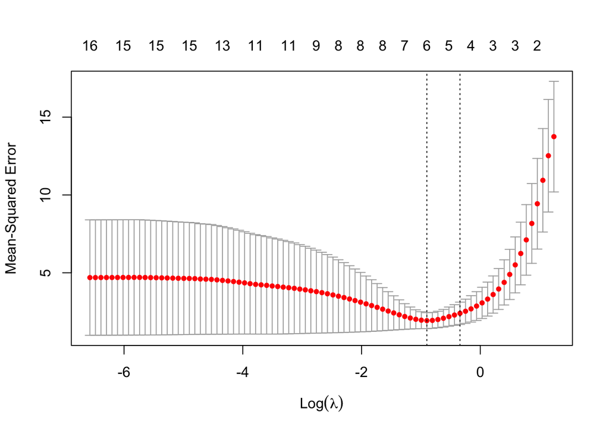

```r
# Fit the Lasso model with lambda_min and lambda_1se
model_lasso <- cv.glmnet(x = as.matrix(train[,-17]), y = train$heart_attack, alpha = 1, nfolds = 8)


# Extract lambda_min and lambda_1se
lambda_min <- model_lasso$lambda.min
lambda_1se <- model_lasso$lambda.1se

plot(model_lasso)
```

```r
predictions_lasso <- predict(model_lasso, as.matrix(test[,-17]))

# Find R-squared value
rsq = 1 - model_lasso$cvm/test[,17]
```

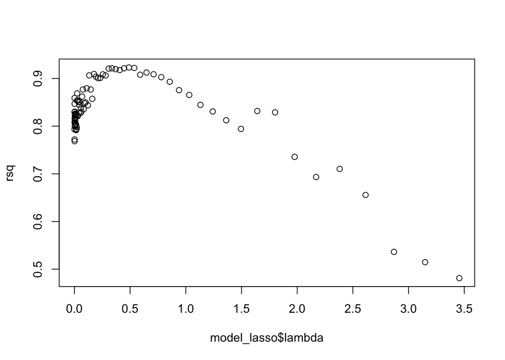

```r
plot(model_lasso$lambda,rsq)
```

```r
model_lasso_min<-glmnet(x = as.matrix(train[,-17]), y = train$heart_attack, alpha = 1, nfolds = 8, lambda = lambda_min)
summary(model_lasso_min)
```

```
##           Length Class     Mode
## a0         1     -none-    numeric
## beta      16     dgCMatrix S4
## df         1     -none-    numeric
## dim        2     -none-    numeric
## lambda     1     -none-    numeric
## dev.ratio  1     -none-    numeric
## nulldev    1     -none-    numeric
## npasses    1     -none-    numeric
## jerr       1     -none-    numeric
## offset     1     -none-    logical
## call       6     -none-    call
## nobs       1     -none-    numeric
```

```r
# Fit the Lasso model with lambda_min
model_min <- glmnet(x = as.matrix(train[,-17]), y = train$heart_attack, alpha = 1, lambda = lambda_min)

# Fit the Lasso model with lambda_1se
model_1se <- glmnet(x = as.matrix(train[,-17]), y = train$heart_attack, alpha = 1, lambda = lambda_1se)

# Calculate R-squared for each model on the test set
#rsq_lin_reg <- summary(lin_reg)$r.squared
Y_pred_min <- predict(model_min, as.matrix(test[,-17]), type = "response")
Y_pred_1se <- predict(model_1se, as.matrix(test[,-17]), type = "response")

SSE_min <- sum((test[,17] - Y_pred_min)^2) #Sum of squared error for residuals
SST <- sum((test[,17] - mean(train[,17]))^2) #sum of squares total

R2_min <- 1 - (SSE_min/SST)

SSE_1se <- sum((test[,17] - Y_pred_1se)^2)

R2_1se <- 1 - (SSE_1se/SST)

sprintf("The R-square from the generalized lineaer model is: %.4f",test.rsq)
```

```
## [1] "The R-square from the generalized lineaer model is: 0.8776"
```

```r
cat("Mean R-squared from 8-fold cross-validation:", mean_rsquared_cv, "\n")
```

```
## Mean R-squared from 8-fold cross-validation: 0.8798833
```

```r
sprintf("The R-squared value from lambda when MSE is min is %.4f", R2_min)
```

```
## [1] "The R-squared value from lambda when MSE is min is 0.8577"
```

```r
sprintf("The R-squared value from lambda when MSE is 1 std. deviation from the min is %.4f", R2_1se)
```

```
## [1] "The R-squared value from lambda when MSE is 1 std. deviation from the min is 0.8294"
```

Q6. What is AIC, and how is it calculated? When to use AICc (corrected AIC)?

AIC stands for Akaike Information Criterion. It is a measure of the relative quality of a statistical model, used to compare different models. It is calculated as AIC = 2k - 2ln(L), where k is the number of parameters in the model, and L is the maximum value of the likelihood function for the model. Lower values of AIC indicate better models.

AICc is a corrected version of AIC that is used when the number of observations is small. AICc = AIC + (2k(k + 1)) / (n - k - 1), where n is the number of observations.